# CH5 : Desion Trees & Rondom Forests

TP5 : Regression tree

> In this practical work, we will build some decision trees for both regression and classification problems. Note that there are many packages to do this in `R` . The tree package is the basic package to do so, while the `rpart17` package seems more widely suggested and provides better plotting features. So we will use the `rpart` package.

# Question 1

Load the Boston dataset from `MASS` package. Split the dataset randomly in half.

```r
library(MASS)
library(caTools)
```

```r
set.seed(18)
Boston_idx = sample(1:nrow(Boston), nrow(Boston) / 2)
# You don't know what we just did?
# open the documentation of the function sample by
# writing ?sample in the R console.
# Note that this is one of the ways to split it randomly and
#it is not necessary the best.
Boston_train = Boston[Boston_idx,]
Boston_test  = Boston[-Boston_idx,]
```

# Question 2

Fit a regression tree to the training data using the `rpart()` function from the `rpart` package. Name the tree `Boston_tree`.

```r
library(rpart)
Boston_tree = rpart(medv~.,Boston_train)
```

> La fonction rpart realise par defaut une estimation des performances de l’arbre par validation croisee a 10 blocs pour chaque niveau de simplification pertinent. Le nombre de blocs se regle au moment de la construction de l’arbre grace au parametre xval de rpart.control

# Question 3

Plot the obtained tree using the following code

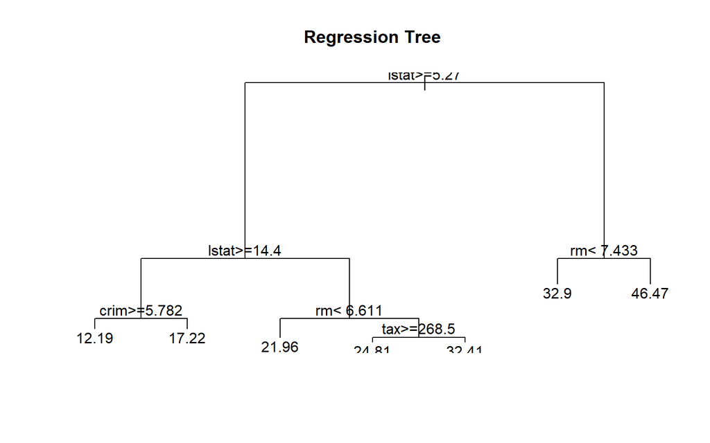

```r
plot(Boston_tree)
text(Boston_tree, pretty = 0)
title(main = "Regression Tree")
```

# Question 4

A better plot can be obtained using the `rpart.plot18` package. Re-plot the tree using it. You can use the `rpart.plot()` function which by default, when the output is continuous, each node shows: the predicted value, and the percentage of observations in the node. You can also use the `prp()` function

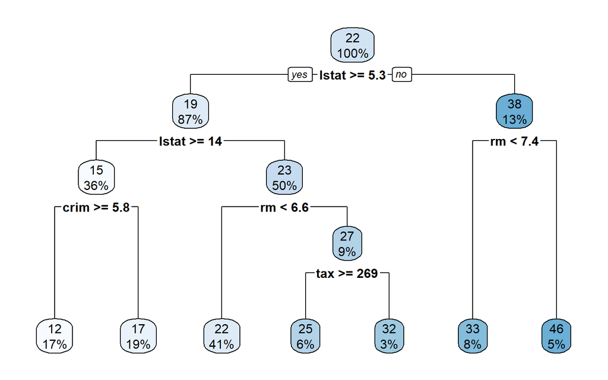

```r
library(rpart.plot)
rpart.plot(Boston_tree)
```

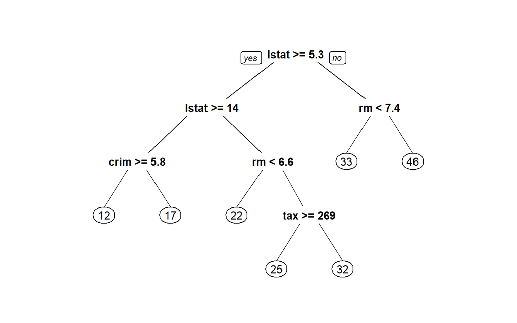

```r
prp(Boston_tree)
```

# Question 5

Print the obtained tree and print its `summary`. Between the things that you can see in the `summary`, the `CP` (complexity parameter) table and the importance of each variable in the model. Print the `CP` table using the `printcp()` function to see the cross validation results. Plot a comparison figure using the `plotcp()` function. You will notice the obtained tree is pruned. This is because `rpart` prunes the tree by default by performing `10-fold cross-validation`.

```r
print(Boston_tree)
```

```
## n= 253
##
## node), split, n, deviance, yval
##       * denotes terminal node
##
##  1) root 253 19858.11000 21.99802
##    2) lstat>=5.27 219  7420.35000 19.49954
##      4) lstat>=14.4 92  1798.17900 14.81522
##        8) crim>=5.7819 44   648.06430 12.18864 *
##        9) crim< 5.7819 48   568.30480 17.22292 *
##      5) lstat< 14.4 127  2141.02400 22.89291
##       10) rm< 6.611 104   991.45380 21.95769 *
##       11) rm>=6.611 23   647.29910 27.12174
##         22) tax>=268.5 16   268.14940 24.80625 *
##         23) tax< 268.5 7    97.28857 32.41429 *
##    3) lstat< 5.27 34  2265.02700 38.09118
##      6) rm< 7.433 21   686.16950 32.90476 *
##      7) rm>=7.433 13   101.48770 46.46923 *
```

```r
summary(Boston_tree)
```

```
## Call:
## rpart(formula = medv ~ ., data = Boston_train)
##   n= 253
##
##           CP nsplit rel error    xerror       xstd
## 1 0.51227092      0 1.0000000 1.0079237 0.12063261
## 2 0.17530106      1 0.4877291 0.6269968 0.08009188
## 3 0.07439632      2 0.3124280 0.4181044 0.06301976
## 4 0.02929834      3 0.2380317 0.3886623 0.06765051
## 5 0.02529297      4 0.2087334 0.3489906 0.06171012
## 6 0.01419376      5 0.1834404 0.3172825 0.05624605
## 7 0.01000000      6 0.1692466 0.3051705 0.05617950
##
## Variable importance
## lstat    rm   age   tax   dis indus   nox  crim   rad    zn black
##    40    17     9     7     7     6     5     5     2     1     1
##
## Node number 1: 253 observations,    complexity param=0.5122709
##   mean=21.99802, MSE=78.49055
##   left son=2 (219 obs) right son=3 (34 obs)
##   Primary splits:
##       lstat   < 5.27    to the right, improve=0.5122709, (0 missing)
##       rm      < 6.978   to the left,  improve=0.4501026, (0 missing)
##       indus   < 7.625   to the right, improve=0.3122330, (0 missing)
##       ptratio < 19.65   to the right, improve=0.2830922, (0 missing)
##       nox     < 0.5125  to the right, improve=0.2710296, (0 missing)
##   Surrogate splits:
##       rm    < 6.978   to the left,  agree=0.917, adj=0.382, (0 split)
##       age   < 17.1    to the right, agree=0.881, adj=0.118, (0 split)
##       crim  < 0.03402 to the right, agree=0.877, adj=0.088, (0 split)
##       zn    < 87.5    to the left,  agree=0.870, adj=0.029, (0 split)
##       indus < 1.605   to the right, agree=0.870, adj=0.029, (0 split)
##
## Node number 2: 219 observations,    complexity param=0.1753011
##   mean=19.49954, MSE=33.88288
##   left son=4 (92 obs) right son=5 (127 obs)
##   Primary splits:
##       lstat   < 14.4    to the right, improve=0.4691352, (0 missing)
##       crim    < 5.84803 to the right, improve=0.3530712, (0 missing)
##       ptratio < 19.9    to the right, improve=0.3072113, (0 missing)
```

[output cut: 74 more lines]

```
##       tax     < 268.5   to the right, improve=0.4354419, (0 missing)
##       ptratio < 18.7    to the right, improve=0.3278305, (0 missing)
##       indus   < 4.415   to the right, improve=0.2124938, (0 missing)
##       rm      < 6.978   to the left,  improve=0.1449609, (0 missing)
##       nox     < 0.5225  to the right, improve=0.1122918, (0 missing)
##   Surrogate splits:
##       indus   < 2.21    to the right, agree=0.783, adj=0.286, (0 split)
##       rm      < 7.1455  to the left,  agree=0.783, adj=0.286, (0 split)
##       ptratio < 13.9    to the right, agree=0.783, adj=0.286, (0 split)
##
## Node number 22: 16 observations
##   mean=24.80625, MSE=16.75934
##
## Node number 23: 7 observations
##   mean=32.41429, MSE=13.89837
```

```r
printcp(Boston_tree)
```

```
##
## Regression tree:
## rpart(formula = medv ~ ., data = Boston_train)
##
## Variables actually used in tree construction:
## [1] crim  lstat rm    tax
##
## Root node error: 19858/253 = 78.491
##
## n= 253
##
##         CP nsplit rel error  xerror     xstd
## 1 0.512271      0   1.00000 1.00792 0.120633
## 2 0.175301      1   0.48773 0.62700 0.080092
## 3 0.074396      2   0.31243 0.41810 0.063020
## 4 0.029298      3   0.23803 0.38866 0.067651
## 5 0.025293      4   0.20873 0.34899 0.061710
## 6 0.014194      5   0.18344 0.31728 0.056246
## 7 0.010000      6   0.16925 0.30517 0.056180
```

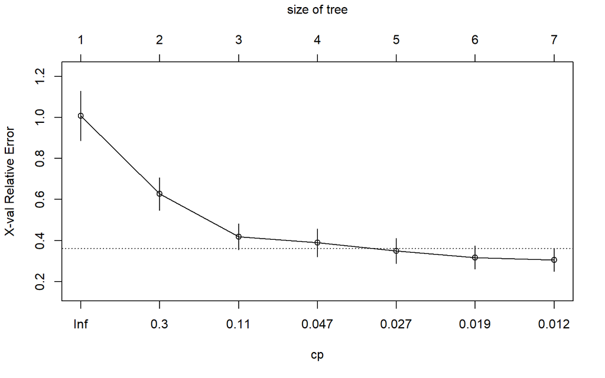

```r
plotcp(Boston_tree)
```

> As a rule of thumb, it is best to prune a decision tree using the cp of smallest tree that is within one standard deviation of the tree with the smallest xerror. In this example, the best xerror is :

> Achieved at :

```r
index_best <- which.min(Boston_tree$cptable[,"xerror"])
index_best
```

```
## 7
## 7
```

```r
#7
```

> And equal to

```r
Boston_tree$cptable[index_best,"xerror"]
```

```
## [1] 0.3051705
```

```r
# 0.3051705
```

> With standard deviation :

```r
Boston_tree$cptable[index_best,"xstd"]
```

```
## [1] 0.0561795
```

```r
# 0.0561795
```

> So, we want the smallest tree with xerror less than 0.30517 + 0.05618 = 0.361

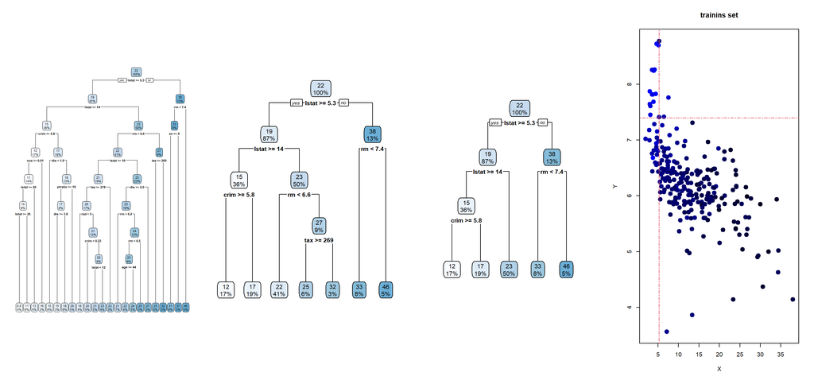

```r
par(mfrow=c(1,4))

Boston_tree = rpart(medv ~ ., data = Boston_train, cp=-1)
rpart.plot(Boston_tree)

Boston_tree = rpart(medv ~ ., data = Boston_train)
rpart.plot(Boston_tree)

Boston_tree <- prune(Boston_tree,cp= 0.02629297)
rpart.plot(Boston_tree)


X <- Boston_train$lstat
Y <- Boston_train$rm
Z <- Boston_train$medv
ZZ = abs(Z)/max(Z)
plot(Y~X, col=rgb(0, 0, ZZ),lwd = 4, main="trainins set")
abline(v=5.3,lty=6,col=2)
abline(h=7.4,lty=6,col=2)
```

> As a rule of thumb, it is best to prune a decision tree using the cp of smallest tree that is within one standard deviation of the tree with the smallest xerror.

# Question 6

Write a function that returns the `RMSE` of two vectors.

```r
RMSE = function(a, b){
  sqrt(mean((a - b)^2))
}
```

# Question 7

Use the function `predict()` to predict the response on the test set. Then calculate the RMSE obtained with tree model

```r
prediction <- predict(Boston_tree, Boston_test)

rmseval <- RMSE(prediction,Boston_test$medv)
rmseval
```

```
## [1] 5.958882
```

# Question 8

Fit a linear regression model on the training set. Then predict the response on the test set using the linear model. Calculate the `RMSE` and compare the performance of the tree and the linear regression model.

```r
regmodel = glm(medv~., data = Boston_train)
predictreg <- predict(regmodel, Boston_test)

rmseval <- RMSE(predictreg,Boston_test$medv)
rmseval
```

```
## [1] 5.016083
```

# Question 9

You can visually compare the performance of both models by plotting the Actual (reality) response values against the predicted values. The model with closer points are to the diagonal (y=x) line is the better one. You can try to reproduce the figure below.

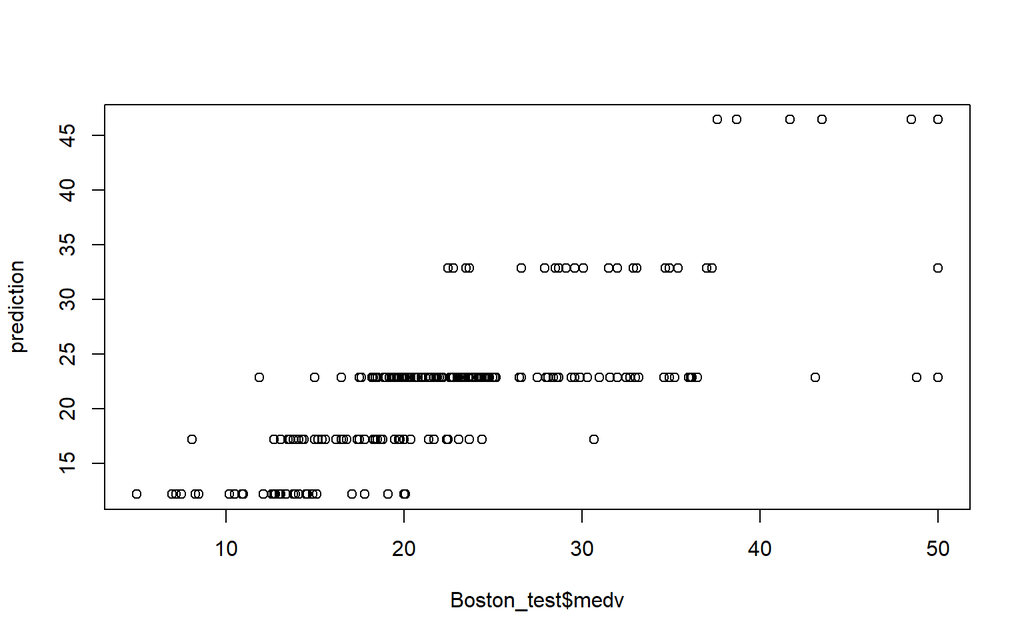

```r
#par(mfrow=c(1,2))
plot(x=Boston_test$medv,
     y=prediction)
```

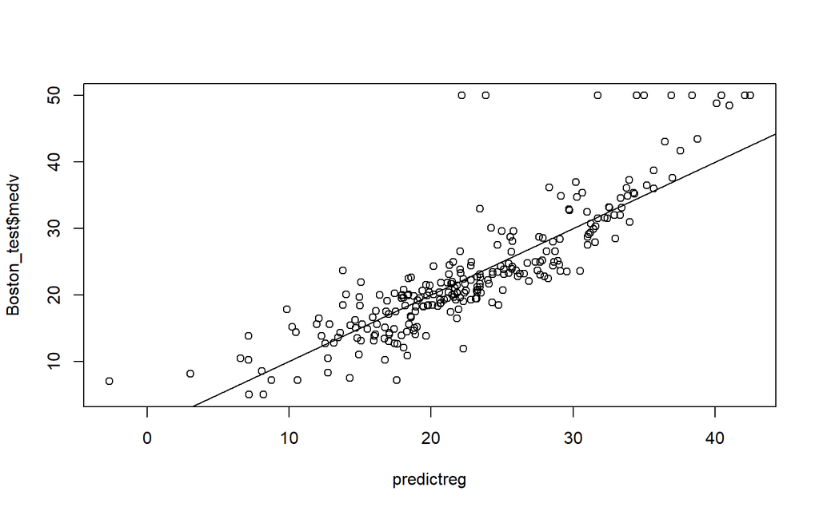

```r
plot(x=predictreg,
     y=Boston_test$medv)
abline(a=0,b=1)
```

# Question 10

```r
#install.packages("randomForest")
library(randomForest)
model2=randomForest(medv~.,Boston_train,importance=TRUE)
model2
```

```
##
## Call:
##  randomForest(formula = medv ~ ., data = Boston_train, importance = TRUE)
##                Type of random forest: regression
##                      Number of trees: 500
## No. of variables tried at each split: 4
##
##           Mean of squared residuals: 12.42275
##                     % Var explained: 84.17
```

```r
summary(model2)
```

```
##                 Length Class  Mode
## call              4    -none- call
## type              1    -none- character
## predicted       253    -none- numeric
## mse             500    -none- numeric
## rsq             500    -none- numeric
## oob.times       253    -none- numeric
## importance       26    -none- numeric
## importanceSD     13    -none- numeric
## localImportance   0    -none- NULL
## proximity         0    -none- NULL
## ntree             1    -none- numeric
## mtry              1    -none- numeric
## forest           11    -none- list
## coefs             0    -none- NULL
## y               253    -none- numeric
## test              0    -none- NULL
## inbag             0    -none- NULL
## terms             3    terms  call
```

# Question 11

```r
prediction2=predict(model2,Boston_test)
RMSE(prediction2,Boston_test$medv)
```

```
## [1] 4.108666
```